# 3.2 统计检验

# 3.2.1 单个总体均值的t检验

## （1）什么是检验？

检验（test）是统计学中最重要的概念之一，在科学研究和实际业务中都有着广泛的应用。用一句话来概括就是：人们希望通过掌握的数据和其他背景知识确认某个假设是否成立（比如某种药物是否有效，股票是否有上扬的趋势，一种汽车的油耗是否为15mpg，一组病人血压的均值是否大于120mmHg）。下面我们来举个栗子。

考虑一个只有赢或者输两种情况的赌局，每次获胜的概率是未知的，这里设为p。一个赌徒想要确认在这个赌局中每次获胜的概率是否是0.5，或者说他希望确认这是一个公平的赌局。如果每次获胜的概率不是（更严格地说是小于等于）0.5，那么这名赌徒就不希望进入这个对他不利的赌局。在这里，这个未知的参数p是关键。假如这名赌徒旁观了其他人参加这个赌局获胜的情况，其他人一共赌了100局，其中获胜30次，我们如何通过这组数据（样本）来判断获胜概率是否是0.5呢？

在这个例子中，我们掌握了赌100次的获胜情况（数据），并且知道这个赌局只有输赢两种情况，每次获胜的概率p都是一样的（背景知识），我们希望确认p=0.5这个假设是否成立。统计学中解决此类问题的思路是：假设未知参数（p）是特定的值，然后通过数据判断这个假设是否合理（建立检验统计量等），如果不合理，我们可以拒绝这个假设；如果合理，那么我们持保留意见，不去拒绝假设。

这里，我们假设p=0.5，统计学中也常常写作，$H_{0}：p=0.5$，也就是原假设：p=0.5。

如果这个赌局是公平的，那么一个人赌100局却只赢30局甚至更少的概率是多少呢？通过计算可以得知这个概率大概是$4\times10^{-5}$，也就是说，在一个公平的赌局下，一个人输那么惨，或者比这还惨的可能性是$4\times10^{-5}$（小概率事件），这看起来不太可能，得是做了多少坏事人品才能这么差。更可能是因为这个赌局本身就是不公平的（p不是0.5）才导致这个人输得那么惨。在这种情况下，我们认为之前的假设是不对的，统计学中也称作拒绝原假设。因此，认为这个赌局并不是公平的，也就是说我们拒绝了p=0.5这个假设。

## （2）学生t检验

对于不同的假设和问题，统计学上有不同的检验来处理，以上的例子只是检验的一个特例而已。今天我们要说的是非常常用的单个总体均值的假设检验，也称为学生t检验。学生t检验简称t检验，最早由William Sealy Gosset于1908年提出。Gosset受雇于都柏林的健力士酿酒厂担任统计学家, 他提出了t检验以降低啤酒质量监控的成本，并于1908年在《Biometrika》期刊上公布t检验，但因为商业机密的原因而被迫使用笔名Student，因此这个检验就叫做学生t检验。那么t检验通常用来解决哪类问题呢？

如果我们有一组从正态总体（背景知识）中抽出的样本（数据），但总体的平均水平未知，我们希望通过这组样本确认总体的平均水平是多少，t检验就大有作为了。在这里我们通过著名的Iris数据来说明一下t检验的思想和在R语言中的实现。

Iris数据测量了三种鸢（yuan，一声）尾花卉的一些值，我们只看山鸢尾（setosa）这种植物的花萼长度的测量。首先我们在R中取出这个数据集：

```r
rm(list = ls())  # 清空工作空间
summary(iris)
```

```
##    Sepal.Length    Sepal.Width     Petal.Length    Petal.Width
##   Min.   :4.300   Min.   :2.000   Min.   :1.000   Min.   :0.100
##   1st Qu.:5.100   1st Qu.:2.800   1st Qu.:1.600   1st Qu.:0.300
##   Median :5.800   Median :3.000   Median :4.350   Median :1.300
##   Mean   :5.843   Mean   :3.057   Mean   :3.758   Mean   :1.199
##   3rd Qu.:6.400   3rd Qu.:3.300   3rd Qu.:5.100   3rd Qu.:1.800
##   Max.   :7.900   Max.   :4.400   Max.   :6.900   Max.   :2.500
##         Species
##   setosa    :50
##   versicolor:50
##   virginica :50
##
##
##
```

```r
(sepal = iris[iris$Species == 'setosa', 1])
```

```
##   [1] 5.1 4.9 4.7 4.6 5.0 5.4 4.6 5.0 4.4 4.9 5.4 4.8 4.8 4.3 5.8 5.7 5.4
##  [18] 5.1 5.7 5.1 5.4 5.1 4.6 5.1 4.8 5.0 5.0 5.2 5.2 4.7 4.8 5.4 5.2 5.5
##  [35] 4.9 5.0 5.5 4.9 4.4 5.1 5.0 4.5 4.4 5.0 5.1 4.8 5.1 4.6 5.3 5.0
```

Iris数据集对50个setosa的花萼进行了测量，假设每个花萼的长度都是来自一个正态分布，但这个正态分布的总体均值$\mu$（位置参数），和总体方差$\sigma^2$（尺度参数）都是不知道的。如果这时候有个植物学家跑过来跟你说，他对基因组的分析表明，这种植物花萼的总体均值是4.5cm，而我们想通过数据来看一看他的分析是否值得信赖。在这里，假设$H_0:\mu=4.5cm$。R可以给我们计算最后的结果，也就是我们是否应该同意$\mu$是4.5cm。

```r
t.test(sepal, mu = 4.5)
```

```
##
##      One Sample t-test
##
##  data:  sepal
##  t = 10.151, df = 49, p-value = 1.223e-13
##  alternative hypothesis: true mean is not equal to 4.5
##  95 percent confidence interval:
##   4.905824 5.106176
##  sample estimates:
##  mean of x
##      5.006
```

看起来结果有一些杂乱，我们教给大家查看结果最快的两种方式，这两种方式是等价的，读者可选用任何一种方式，但这两种方法却忽略了一些其他信息，稍后向大家说明。

1. 红字p-value：如果小于0.05那么我们就拒绝原假设，也就是说我们认为花萼的均值不是4.5cm。如果p-value大于0.05，那么我们就不能拒绝原假设，也就是说我们认为这名植物学家说的话很可能是正确的，花萼的均值很有可能是4.5cm，我们并不能拒绝这一说法。
2. 如果4.5不在绿字95 percent confidence interval的区间里面，也就是说如果4.5不在4.905824，5.106176之间的话，（在0.05的显著性水平下）拒绝原假设，否则的话不能拒绝原假设。

## （3）t检验进阶

上面就是t检验的思想和应用，下面我们稍微看一些t检验的变种形式和一些其他的信息。

1. 进行t检验的一个重要前提是我们的数据是来自一个正态分布，其中方差未知。如果我们知道方差的话，那么我们应该利用这一信息从而获得更佳的结果，这时候我们应该使用z检验（检验统计量服从正态分布）。
2. 那么如何确认数据是否来自正态分布呢？一般来说有两种方法，第一种是问专家，查看历史情况。当然这是比较理想的情况，如果我们对这一数据没有太多的背景知识，我们可以利用Q-Q图或者一些正态性检验（非参数检验方法）来判断数据是否来自正态分布。
3. 如果数据不是来自于正态分布那怎么办呢？在样本量很大的情况下，我们还是可以继续使用t检验的，虽然它不是特别精确了。当然如果读者还是想保守一点的话可以使用非参数的方法，这里就不再赘述了。2和3只是给大家提供一点变招，如果大家在实际数据分析中遇到类似的问题也有章可循。
4. 如果这名植物学家说花萼的长度应该是一个大于4.5cm的数，但是具体是多少不太清楚。在这种情况下我们只需要调整一个参数就可以（单边假设检验）。

```r
t.test(sepal, mu = 4.5, alternative = "less")
```

```
##
##      One Sample t-test
##
##  data:  sepal
##  t = 10.151, df = 49, p-value = 1
##  alternative hypothesis: true mean is less than 4.5
##  95 percent confidence interval:
##       -Inf 5.089575
##  sample estimates:
##  mean of x
##      5.006
```

这里alternative参数是指备择假设（的方向）。

5. p-value反映了我们有多大的信心去拒绝原假设。列举前面硬币的例子，如果我们观察到100局中只获胜了10局，那么我们的数据更加倾向于去拒绝原假设，也就是说我们更有信心去拒绝原假设。这种情况下p-value都是很小的。换句话说，p-value越小，我们越有信心去拒绝原假设。
6. 也许有些读者已经注意到t.test()输出结果中的confidence interval了，对了，这就是置信区间。假设检验和置信区间存在一一对应的关系，调用函数t.test()的时候R会一并给出位置参数$\mu$的置信区间。对于检验来说，只要我们假设的数字（这里是4.5）不在置信区间内，我们就拒绝原假设，否则我们就不能拒绝原假设。
7. 有些读者可能会问为什么一定要p-value小于0.05才能拒绝原假设呢？这里就会牵扯出显著性水平这个比较抽象的概念。在此我们不对显著性追根溯源（醒醒，这是R语千寻，不是数理统计课），只是提醒读者，一般显著性水平会选择0.1，0.05，和0.01这三个水平。

## （4）总结

当我们有一组来自未知均值、未知方差的正态分布的样本，想判断它的总体均值是否等于（有时是大于或者小于）某个给定值的情况下，单样本t检验就可以派上用场了。我们可以在R中调用t.test()函数来进行单样本的t检验，t.test()的部分参数列表如下：

```r
help("t.test")
```

```
##  starting httpd help server ... done
```

x：待检验的数据集，要求是numeric vector

alternative：备择假设的方向，分别对应双边、左侧和右侧检验

mu：原假设中想要检验的总体均值

conf.level：置信水平，对应着输出的置信区间

注：

1. 做单边假设检验的时候总是令人头晕，搞不清哪边做原假设哪边做备择假设。一般情况下，我们能够控制犯第一类错误的概率（拒真），也就是我们更希望得到拒绝原假设的结论，因此常常把样本支持的证据放在备择假设。

2. 本文基本上列举了t检验在实际数据分析中的一些要点（契合R语言操作），想要了解更多理论基础的读者，可以参考数理统计教材里面的假设检验章节。

# 3.2.2 两总体均值对比

上一节我们介绍了单个总体均值的检验问题，它是利用样本提供的信息来判断原假设是否成立。你只要把数据扔给R，然后一个t.test()就搞定了，是不是很简单？本节我们要讲的是两总体的均值对比，怎么个对比法，先举个栗子。

某公司想要检验新生产的一批药对改善睡眠效果如何，假如老板说，小王你给我检验一下这药平均效果怎样啊？小王心里嘀咕了：你要检验它的均值等于多少呢？与其面壁苦想不如机智地跟老板说，老板你再给我这群人没有用这批药之前的睡眠情况数据，我就能告诉你这药有没有效果！这就是今天要讲的两总体均值的t检验。

两总体均值t检验的目的是检验两个正态分布总体的均值之间是否有显著差异。举个简单的两独立总体的栗子，我们想要比较两个不同品种鸢尾花的花瓣平均长度是否一样，在R里面怎么实现呢？回想一下，单样本总体均值检验我们用了t.test()，那么这对两个总体是否一样适用呢？答案是肯定的。快快打开R跟我一起敲下下面的代码啦~

```r
data("iris")
x = iris[iris$Species == 'setosa', 3]
y = iris[iris$Species == 'versicolor', 3]
t.test(x, y)
```

```
##
##      Welch Two Sample t-test
##
##  data:  x and y
##  t = -39.493, df = 62.14, p-value < 2.2e-16
##  alternative hypothesis: true difference in means is not equal to 0
##  95 percent confidence interval:
##   -2.939618 -2.656382
##  sample estimates:
##  mean of x mean of y
##      1.462     4.260
```

可能有读者要说了，这很简单嘛，p值小于0.05，拒绝原假设啊，那就是两个总体花瓣平均长度不等，任务完成！客官且慢且慢，请回头再看一眼前文提到的两样本均值t检验的定义，有没有看到正态两个字呀！还有还有，你考虑这两个总体的方差了么？t.test()默认两总体方差是不等的，所以我们上面所做的检验是基于两总体方差不等的假设而做的检验，如果万一不凑巧这两总体方差相等了呢？其实也很简单，只要在t.test()里添上`var.equal=TRUE`就好啦！代码虽然简单，但是做t检验一定要有这个意识哦，是不是正态，是不是满足方差齐性的假设。

注：在实际数据分析的时候，往往采取“放弃治疗”的态度，不管三七二十一，直接就t检验了。

呀呀呀，我们怎么把小王给忘了，赶紧回来，继续上面的例子。老板很容易地给小王拿来了两组数据，一组是用了这个药的群体的睡眠情况，一组是这群人还没有用这个药之前的睡眠情况，说，小王啊拿去给我看看这药有没有用，有用咱就加大宣传力度，肯定顾客盈门~

小王想，这多简单啊，一个t.test()就秒秒钟搞定！假设老板给老王拿来的数据集就是R中自带的sleep数据集，虽然数据量有点小，每一组只有10个样本，但是为了练习方便大家就将就着用吧，用小数据学会了这个方法，就可以在大数据面前从容淡定啦！首先我们在R中调出这个数据集，看下数据集长啥样子，在R里help一下我们可以看到这个数据集第一列代表样本的睡眠情况（睡眠增加时间），第二列是样本所属组别（1和2，可以理解成我们所说的用药之前和用药之后），第三列是个体的ID，注意到这是同样10个人采取的两组措施。

```r
data(sleep)
head(sleep)
```

```
##    extra group ID
##  1   0.7     1  1
##  2  -1.6     1  2
##  3  -0.2     1  3
##  4  -1.2     1  4
##  5  -0.1     1  5
##  6   3.4     1  6
```

为了更好地说明是两个总体的样本数据，我们手动创造两个样本数据集！将group为1的作为第一组，group为2的作为我们的第二组，然后，扔进t.test()。

```r
x = sleep[sleep$group == 1, 1]
y = sleep[sleep$group == 2, 1]
t.test(x, y)
```

```
##
##      Welch Two Sample t-test
##
##  data:  x and y
##  t = -1.8608, df = 17.776, p-value = 0.07939
##  alternative hypothesis: true difference in means is not equal to 0
##  95 percent confidence interval:
##   -3.3654832  0.2054832
##  sample estimates:
##  mean of x mean of y
##       0.75      2.33
```

啊，一看，p值是0.07939，（在0.05的显著性水平下）不能拒绝两组均值相等的原假设，也就是说，用药和不用药效果是一样的，老板听到这个心该碎了一地了吧！可是，别着急掉眼泪，你看看，这两组样本和之前的独立样本能一样么？老板明明说了这是同一组人用药前和用药后的数据呀，注意，是同一组人！咱总不能捂住耳朵硬生生给它一个两总体独立的假设吧。其实，这就是两总体均值t检验的第二种类型，两配对总体均值的检验。

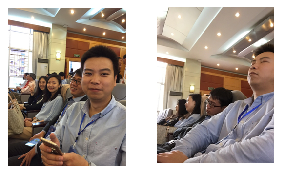

图示 配对样本数据示意图，左：开会前；右：开会中。会议“疗效”显著，妈妈再也不用担心我失眠了！

可能有读者要着急了，那t.test()不能用了么，宝宝好不容易学会这一招，哭。莫慌莫慌！只要在t.test()里面让paired=TRUE即可。首先看结果，p值小于0.05，答案是拒绝原假设！而且两组均值差异估计是-1.58，第二组的均值要比第一组的大，看来这药有效果啊。看，检验之前分清是独立总体还是配对总体有多重要，一不小心，你就要挡住老板的财路了，后果多严重！

```r
x = sleep[sleep$group == 1, 1]
y = sleep[sleep$group == 2, 1]
t.test(x, y, paired = TRUE)
```

```
##
##      Paired t-test
##
##  data:  x and y
##  t = -4.0621, df = 9, p-value = 0.002833
##  alternative hypothesis: true difference in means is not equal to 0
##  95 percent confidence interval:
##   -2.4598858 -0.7001142
##  sample estimates:
##  mean of the differences
##                    -1.58
```

可能爱动脑筋的读者已经发现，这配对样本t检验不就是单样本t检验么？可不是嘛，两个样本数据一做差，不就变成一个样本了。让我们来看看结果是不是一样？

```r
x = sleep[sleep$group == 1, 1]
y = sleep[sleep$group == 2, 1]
t.test(x - y)
```

```
##
##      One Sample t-test
##
##  data:  x - y
##  t = -4.0621, df = 9, p-value = 0.002833
##  alternative hypothesis: true mean is not equal to 0
##  95 percent confidence interval:
##   -2.4598858 -0.7001142
##  sample estimates:
##  mean of x
##      -1.58
```

哇，猜对了的读者有没有成就感满满啊，原来配对总体均值t检验和单总体均值t检验完全等价啊！

最后，我们来做个总结陈词。有以下需要注意的点：

- 两总体的t检验，比较的是总体均值。一般情况下，我们想比较的是两总体均值是否相等，说专业一点叫做是否有显著差异，这时原假设是$H_0:\mu_1=\mu_2$。如果你有特定的研究目的，也可以检验它们的差异是否等于某个特定的值，即$H_0:\mu_1-\mu_2=\Delta$。
- 做检验的时候，一定要搞清楚数据是独立还是配对，两种情况下使用的检验统计量不同，得到的结论也有差异。在t.test()里面，可以非常容易地用paired=TRUE来指定配对数据的情形。
- 大家在学习t检验的时候，会学习各种假设各种情形，比如总体是正态分布，两总体方差已知、未知、比值已知等。学习理论知识的时候，搞清楚这些事情非常有必要，帮你形成完整的知识体系，打下坚实的理论基础。但是在做实际数据分析的时候，往往就是“臣妾做不到”，假设不满足。在大样本的情况下，我们也就直接使用这些统计方法了。

另外要注意的是，在推论时一定要记住统计具有不确定性，即任何推论都是假定的，都是有一定概率性的，即有可能对也有可能错，所以下结论时切忌使用“肯定”、“一定”等词语。如果样本量非常小，通常推论就会犯错误，所以案例中老板的药不一定会改善睡眠质量的哈，毕竟咱只有10个样本~